# Not *How Much*, but *How Well*: Quality of Movement Analysis

## Model Details

Variable importance may be enlightening. Maybe we’ll see if any particular measurements stand out as particularly indicative of good or bad movements.

```r
varImp(modrf$finalModel) %>% mutate(names = row.names(.)) %>% arrange(desc(Overall)) %>% head(10)
```

```
##      Overall             names
## 1  2965.7866        num_window
## 2  1858.9375         roll_belt
## 3  1110.5897     pitch_forearm
## 4   892.5217          yaw_belt
## 5   879.0149 magnet_dumbbell_z
## 6   788.5509 magnet_dumbbell_y
## 7   697.8030        pitch_belt
## 8   564.6941      roll_forearm
## 9   393.7598 magnet_dumbbell_x
## 10  369.9687   accel_forearm_x
```

Oddly, the ever-increasing `num_window` variable is the most important value for predicting movement type. This implies that movement types correlate with the time of data collection. I’d be interested to rebuild this model without that variable, its inclusion was actually an oversight. But the model performs well (see below), so I’d rather not change it now.

Interestingly, the rest of the measurements are mainly positional: x, y, z, pitch, roll, and yaw. Only one measurement deals with acceleration. And all 9 of the top 9 *actual* measurements are from just the belt, forearm, and bumbbell.

It’s possible that fewer, less-complex measurement devices could be used to provide the same quality of movement class prediction. The implication is cheap, effective movement coaching!

## Validation

To run this model on the testing data, it must be cleaned in the same way the training data was cleaned – save any modifications of the `classe` variable, which doesn’t exist in the testing set.

All that’s left is to predict the movement classes for these 20 new records

```r
predict(modrf$finalModel, testfiltered)
```

```
##  1  2  3  4  5  6  7  8  9 10 11 12 13 14 15 16 17 18 19 20
##  B  A  B  A  A  E  D  B  A  A  B  C  B  A  E  E  A  B  B  B
## Levels: A B C D E
```

So how does this model fare?

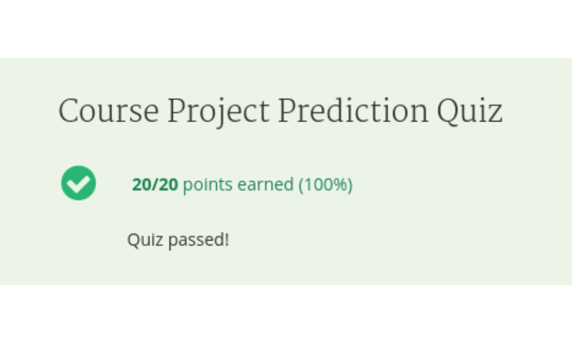

[Course Project Prediction Quiz: 20/20. Quiz Passed!]

Well enough! This project has been the most exciting yet, and I’m interested to see if anyone has yet capitalized on the personal-training possibilities of this technology. I’d love to try it myself :-).

## References

Breiman, L.; Cutler, A. [Random Forests](http://www.stat.berkeley.edu/~breiman/RandomForests/cc_home.htm). 2001. Retrieved July 13, 2016, from http://www.stat.berkeley.edu/~breiman/RandomForests/cc_home.htm

Velloso, E.; Bulling, A.; Gellersen, H.; Ugulino, W.; Fuks, H. [Qualitative Activity Recognition of Weight Lifting Exercises](http://groupware.les.inf.puc-rio.br/work.jsf?p1=11201). Proceedings of 4th International Conference in Cooperation with SIGCHI (Augmented Human ’13) . Stuttgart, Germany: ACM SIGCHI, 2013.